# End-Semester Project

Bivariate Analysis between GDP per capita, Sanitation and Life Expectancy across Nations in 2010

Aman Das [BS2206]

Raj Pratap Singh [BS2219]

Shreyansh Mukhopadhyay [BS2147]

# Introduction

## Overview

Sanitation of oneself is one of the basic duties of a human being. We know poor sanitation is linked to transmission of diarrhoeal diseases such as cholera and dysentery, as well as typhoid, intestinal worm infections and polio which directly affect the health of an individual.

Also know that the Gross Domestic Product per capita of a country basically tells about the wealth of a country. So, in this project Our *Aim* is to determine how these features affect the *Health* of the citizens. out Life expectancy calculated for the year is based on the ages at the time of death of all the people who have deceased in that particular year. Also, in most cases it can tell about the current health condition of the country. Suppose the country is being hit by an epidemic, we can see that the people who might have lived longer if they had been unaffected by the epidemic. Hence we can use *Life Expectation* as a measurable proxy for health.

Our *Aim* is to determine which features more directly affect the *Life Expectation* of the citizens.

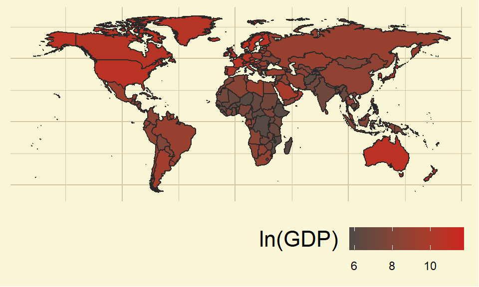

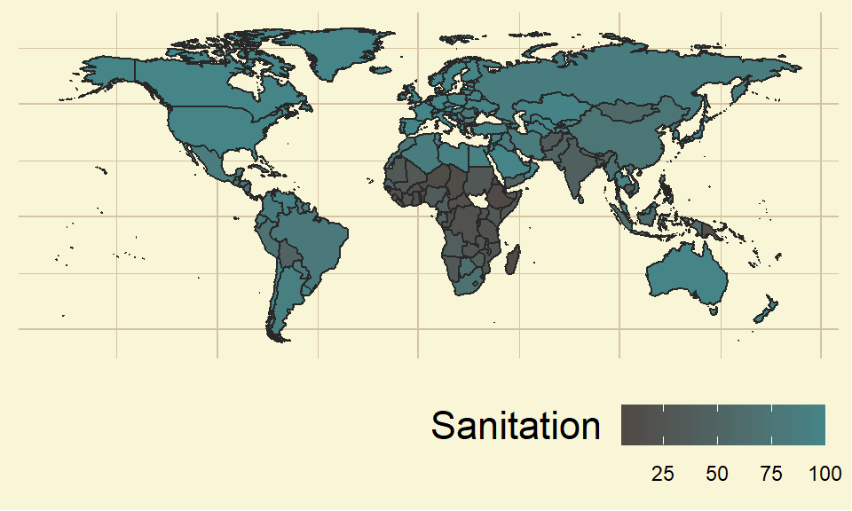

$~$ $~$

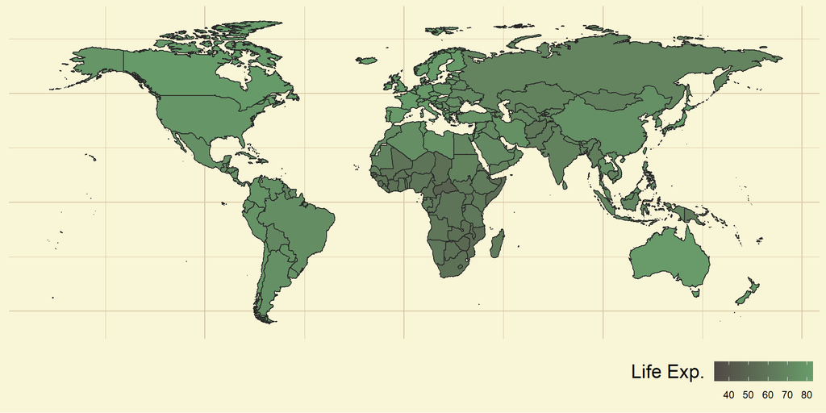

## Data Points

This presentation demonstrates the capabilities of *Bivariate Analysis* on data-sets, to infer relationship between various features of Nations. The co-variates taken in consideration are as follows:

- **log of GDP per capita**: Logarithm ( base $e$) of Gross Domestic Product (in $) per citizen, adjusted for Inflation. [*lngdp*]
- **Sanitation Access %**: Percentage of people using at least basic Sanitation facilities, not shared with other households. [*snt*]
- **Life Expectancy**: The average number of years a newly born child would live, provided current mortality patterns hold. [*lfx*]

## Data

```r
script.dir <- getSrcDirectory(function(x) {x})
# setwd(script.dir)

numerise = function(x){
  x[grepl("k$", x)] <- as.numeric(sub("k$", "", x[grepl("k$", x)]))*10^3
  x <- as.numeric(x)
  return(x)
}

d1_raw = read.csv(file.path(".","Data","gdp.csv"), fileEncoding = 'UTF-8-BOM')
d2_raw = read.csv(file.path(".","Data","sanitation.csv"), fileEncoding = 'UTF-8-BOM')
d3_raw = read.csv(file.path(".","Data","life_expectancy.csv"), fileEncoding = 'UTF-8-BOM')

yearname = "X2010"

d1 = d1_raw[!is.na(numerise(d1_raw[, yearname])),][,c("country", yearname)]
colnames(d1)[2] = "lngdp"
d2 = d2_raw[!is.na(numerise(d2_raw[, yearname])),][,c("country", yearname)]
colnames(d2)[2] = "snt"
d3 = d3_raw[!is.na(numerise(d3_raw[, yearname])),][,c("country", yearname)]
colnames(d3)[2] = "lfx"

dtemp = merge(x = d1, y = d2, by = "country")
d = merge(x = dtemp, y = d3, by = "country")

d$lngdp = log(numerise(d$lngdp))

write.csv(d, "./Data/assembled.csv")

kable(head(d, 6L))
```

| country | lngdp | snt | lfx |
| --- | --- | --- | --- |
| Afghanistan | 6.265301 | 34.9 | 60.5 |
| Albania | 8.183118 | 95.2 | 78.1 |
| Algeria | 8.273847 | 87.0 | 74.5 |
| Andorra | 10.454495 | 100.0 | 81.8 |
| Angola | 8.291547 | 41.1 | 60.2 |
| Antigua and Barbuda | 9.546813 | 86.3 | 75.9 |

<sub>FREE DATA FROM UN, [WORLD BANK](https://worldbank.org), [WHO](https://who.org), [IMHE](http://www.healthdata.org/) VIA [GAPMINDER.ORG](https://gapminder.org), [CC-BY LICENSE](https://creativecommons.org/licenses/by/2.0/).</sub>

# Elementary Univariate Analysis

## Measures of Central Tendency

*Mean or Arithmetic Mean* $\bar{x}$, *Median* $\operatorname{median}(x)$ and *Mode* $\operatorname{mode}(x)$ are some measures of *central tendency* in the sample.

**Formulae**

$$\begin{aligned}
x = \{x_1, x_2, \ldots,x_{n-1}, x_n\} &&
\operatorname{mean}(x)=\bar{x} = \frac{1}{n} \sum _{i=1}^{n}(x_{i})
\end{aligned}$$
$$\begin{aligned}
\operatorname{median}(x)= \frac{x_{\lfloor\frac{n+1}{2}\rfloor}+x_{\lfloor\frac{n+2}{2}\rfloor}}{2} &&
\operatorname{mode}(x) = x_i \text{ s.t. } \operatorname{Pr}(x_i) = \operatorname{sup}(\operatorname{Pr}(x))
\end{aligned}$$

Note: $f_i$ is the frequency of the i<sup>th</sup> observation. $x_{(i)}$ is the i<sup>th</sup> largest observation.

```r
getmode <- function(v) {
 uniqv <- unique(v)
 freq = max(tabulate(match(v, uniqv)))
 res = uniqv[which.max(tabulate(match(v, uniqv)))]
 if (freq == 1) res = NULL
 return(res)
}

d_central = data.frame(
  row.names = "Variable",
  Variable = c(
    "*ln(GDP)*",
    "*Sanitation*",
    "*Life Exp.*"
  ),
  Mean = c(
    mean(d$lngdp),
    mean(d$snt),
    mean(d$lfx)
  ),
  Median = c(
    median(d$lngdp),
    median(d$snt),
    median(d$lfx)
  ),
  Mode = c(
    getmode(d$lngdp),
    getmode(d$snt),
    getmode(d$lfx)
  )
)

kable(
  d_central,
  col.names = c(
    "$\\quad \\quad \\bar{x}$",
    "$\\operatorname{median}(x)$",
    "$\\operatorname{mode}(x)$"
  ),
  digits=5
)
```

[output not shown]

$~$

- Notice that mode of Sanitation is 100. Thus a large number of countries have universal access to basic sanitation infrastructure.

## Measures of Dispersion

*Range* $\operatorname{range}(x)$, *Semi-Interquartile Range* $\operatorname{SIR}(x)$, *Mean Deviation about x’* $\operatorname{MD}_{(x')}(x)$, *Variance* $s_x^2$, *Standard Deviation* $s_x$ are some measures of *dispersion* in the sample.

**Formulae**

$$\begin{aligned}
\operatorname{range}(x)=|x_{(n)} - x_{(1)}| &&
\ Q_1 = \operatorname{median}(x_{(1)}, \ldots ,x_{(\lfloor \frac{n+1}{2} \rfloor)}) &&
\end{aligned}$$
$$\begin{aligned}
\ Q_3 = \operatorname{median}(x_{(\lfloor \frac{n+2}{2} \rfloor)}, \ldots , x_{(n)}) &&
\operatorname{MD}_{(x')}(x) = \operatorname{mean}(|x_i-x'|)
\end{aligned}$$
$$\begin{aligned}
\operatorname{SIR}(x)=\frac{|Q_1-Q_3|}{2} &&
s_x = \sqrt{\operatorname{mean}([x_i - \bar{x}]^2)} &&
s^2_x= (s_x)^2
\end{aligned}$$

```r
getmd = function(x, center = mean(x)){
  md = mean(
    abs(
      x - rep(center, length(x))
      )
    )
  return(md)
}
d_disp = data.frame(
  row.names = "Variable",
  Variable = c(
    "*ln(GDP)*",
    "*Sanitation*",
    "*Life Exp.*"
  ),
  Range = c(
    max(d$lngdp) - min(d$lngdp),
    max(d$snt) - min(d$snt),
    max(d$lfx) - min(d$lfx)
  ),
  SIR = c(
    IQR(d$lngdp)/2,
    IQR(d$snt)/2,
    IQR(d$lfx)/2
  ),
  MD = c(
    getmd(d$lngdp),
    getmd(d$snt),
    getmd(d$lfx)
  ),
  variance = c(
    (sd(d$lngdp))^2,
    (sd(d$snt))^2,
    (sd(d$lfx))^2
  ),
  SD = c(
    sd(d$lngdp),
    sd(d$snt),
    sd(d$lfx)
  )
)

kable(
  d_disp,
  col.names = c(
    "$\\operatorname{range}(x)$",
    "$\\operatorname{SIR}(x)$",
    "$\\operatorname{MD}_{(\\bar{x})}(x)$",
    "$\\quad \\quad \\quad \\quad s_x^2$",
    "$\\quad \\quad \\quad \\quad s_x$"
  ),
  digits=5
)
```

[output not shown]

$~$

- We can compare $s_x$ to $\bar{x}$ and observe that there is a high variation in Sanitation amongst countries.
- GDP per capita varies drastically across the $e$<sup>6.044354</sup> range.

## Measures of Shape

Coefficients of *Skewness* $g_1$ and *Kurtosis* $g_2$ describe the symmetry and extremity of tails of the sample distribution.

**Formulae**

$$\begin{aligned}
m_k = \operatorname{mean}([x-\bar{x}]^k) &&
g_1 = \frac{m_3}{{m_2}^{\frac{3}{2}}} &&
g_2 = \frac{m_4}{{m_2}^2}
\end{aligned}$$

```r
d_shape = data.frame(
  row.names = "Variable",
  Variable = c(
    "*ln(GDP)*",
    "*Sanitation*",
    "*Life Exp.*"
  ),
  Skewness = c(
    skewness(d$lngdp),
    skewness(d$snt),
    skewness(d$lfx)
  ),
  Kurtosis = c(
    kurtosis(d$lngdp),
    kurtosis(d$snt),
    kurtosis(d$lfx)
  )
)

kable(
  d_shape,
  col.names = c(
    "$g_1$",
    "$g_2$"
  ),
  digits=5
)
```

|  | $g_1$ | $g_2$ |
| --- | --- | --- |
| *ln(GDP)* | 0.09619 | 2.14435 |
| *Sanitation* | -0.85989 | 2.27111 |
| *Life Exp.* | -0.87903 | 4.02465 |

- ln(GDP) is nearly symmetrical, while Sanitation and Life Exp. are highly left-skewed.
- This indicates majority of countries have good sanitation system, and citizen health.
- ln(GDP) and Sanitation are platykurtic, while Life Exp. is leptokurtic.

## Density Plot

*Density plots* help us in estimating the form, location and spread of the distribution.

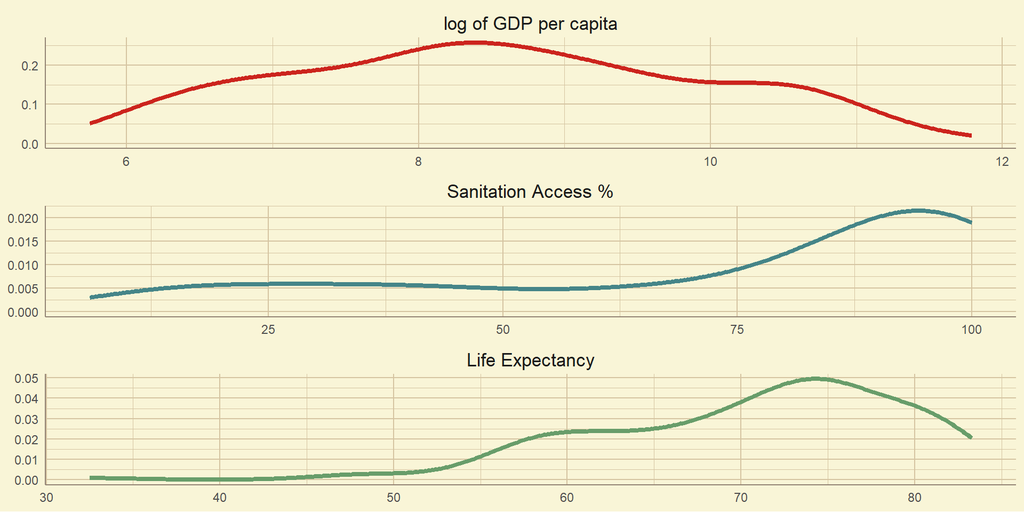

```r
labelfunction = function(val1){
  return(list(c(
    "log of GDP per capita",
    "Sanitation Access %",
    "Life Expectancy"
  )))
}
ggplot(stack(d[2:4]), mapping = aes(x = values))+
geom_density(aes(color=ind), linewidth=rel(1.5))+
labs(
  x=NULL,
  y=NULL
  )+
mytheme+
mycolor+
facet_wrap(~ind, scales="free", labeller = labelfunction, ncol=1)+
  theme(legend.position="none",
        strip.text.x = element_text(size = rel(1.5))
  )
```

From the density plots, we can infer the following:

- The density of the log of GDP per capita is symmetric as supported by the fact that the skewness was close to 0.
- The other two density plots appear left skewed as supported by negative skewness.
- Therefore, these plots confirm our previous inferences.

## Box Plot

*Box plots* help us detect potential outliers. They also help us in estimating location and skewness of the distribution.

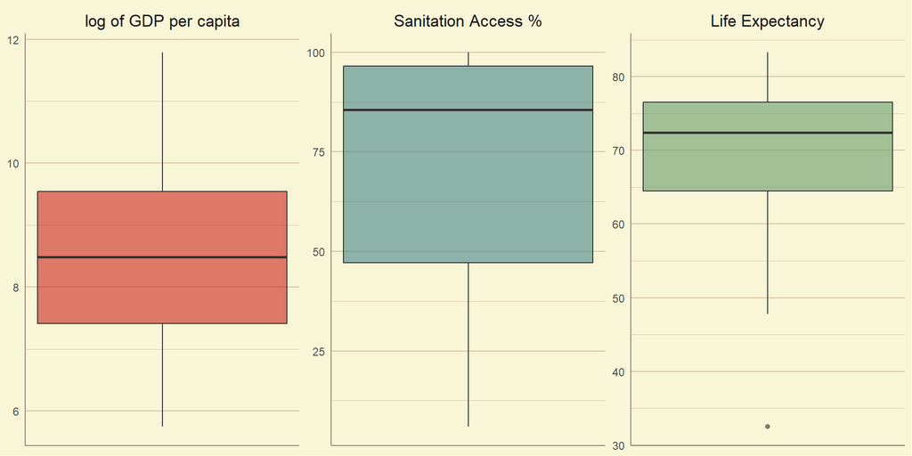

```r
labelfunction = function(val1){
  return(list(c(
    "log of GDP per capita",
    "Sanitation Access %",
    "Life Expectancy"
  )))
}
ggplot(stack(d[2:4]), mapping = aes(y = values))+
geom_boxplot(aes(fill=ind), alpha=0.6)+
labs(
  x=NULL,
  y=NULL
  )+
mytheme+
mycolor+
facet_wrap(~ind, scales="free", labeller = labelfunction)+
  theme(axis.text.x=element_blank(),
        legend.position="none",
        strip.text.x = element_text(size = rel(1.5)),
        panel.grid.minor.x = element_blank(),
        panel.grid.major.x = element_blank()
  )
```

From the box plots we can infer the following:

- The median seems to be in the centre of the quartiles for the ln(gdp) distribution, and it’s closer to the 2nd quartile for the other two distributions.
- So, we can say that the distributions of the sanitation access and life expectancies are left skewed which further confirms the previous inferences.
- We observe one outlier in the Life Expectancy dataset. It is Haiti at 32.5 years. This is due to the cholera epidemic that broke out in the year 2010. Moreover this confirms our assumption that life expectancy is a very good proxy for health.

# Scatter Plot

*Scatter plots* help us estimate the type of relationship between variables. They give a good intuition whether the variales are related or not.

```r
sctrplot = function(
    d, x_map, y_map,
    x_lab=waiver(), y_lab=waiver(),
    title=waiver()
){
  plot1 = ggplot(d, mapping = aes(x = x_map, y = y_map))+
    geom_point(
      alpha=0.6
    )+
    mytheme+
    labs(
      x=x_lab,
      y=y_lab,
      title=title
    )

  return(plot1)
}
```

## Sanitation vs. GDP per Capita

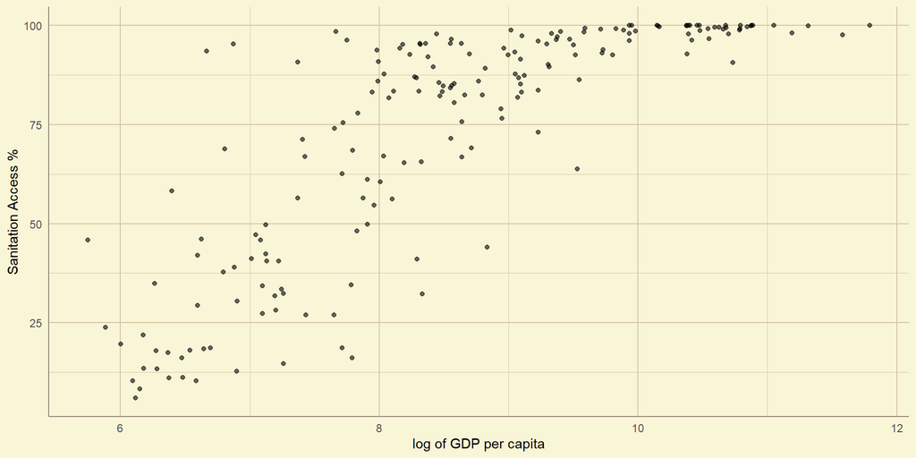

- We observe from the scatter plot that the correlation between ln(gdp) and sanitation access appears to be mostly linear for countries with ln(gdp) less than 10.
- Also, we see that the sanitation access is quite high for the countries with ln(gdp) above 10 for the countries with and is very close to 100% for countries with ln(gdp) above 11.

## Life Expectancy vs. GDP per Capita

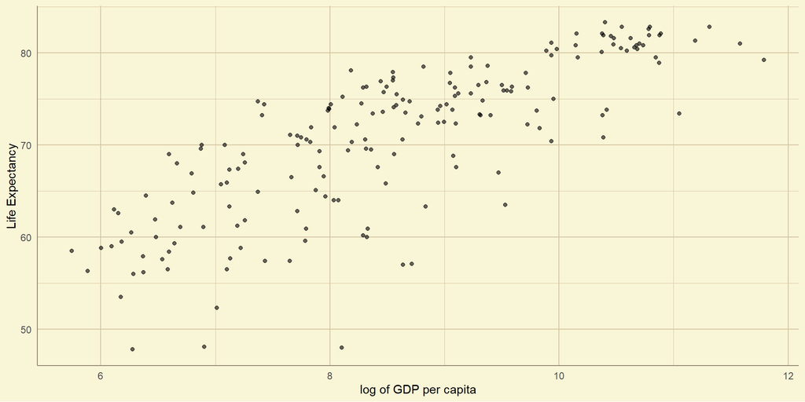

- We can see that except for some countries with very low life expectancies, the correlation between the variables is appearing to be linear.
- The countries like the Central African Republic, Zambia, Zimbabwe have very low life expectancies due to endemic poverty and weak governance, contributing to a dire health situation

## Life Expectation vs. Sanitation

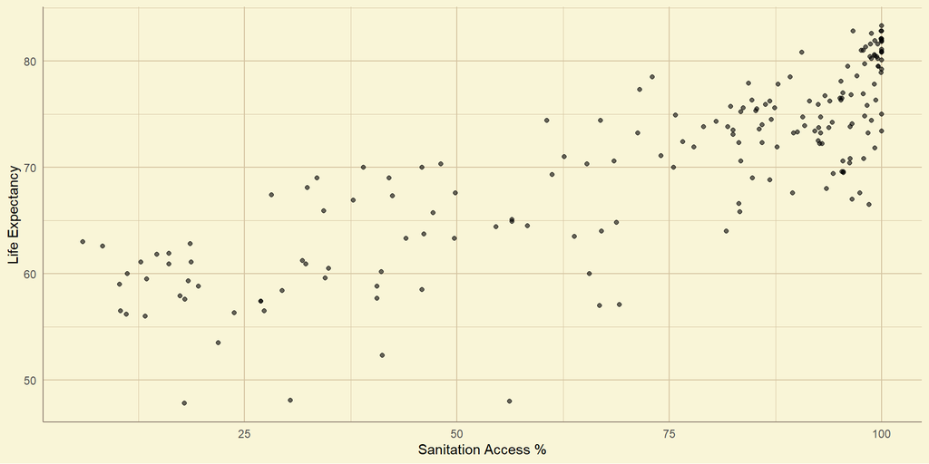

- In this plot too, we can see that the correlation appears to be linear between life expectation and sanitation. We also observe that there is clustering around the top right side of the plot, which is supported by the box plots of both the distributions.

# Bivariate Statistics

## Correlation Coefficients

*Correlation* is any relationship, causal or spurious, between two random variables $x$, $y$.

*Pearson’s* $r$, *Spearman’s* $r_s$, and *Kendall’s* $\tau$ are some correlation coefficients. These estimate the linear correlation between two variables.

```r
d_cor = data.frame(
  row.names = "Variable",
  Variable = c(
    "*Sanitation vs. ln(GDP)*",
    "*Life Exp. vs. ln(GDP)*",
    "*Life Exp. vs. Sanitation*"
  ),
  Pearson = c(
    cor(d$snt, d$lngdp, method="pearson"),
    cor(d$lfx, d$lngdp, method="pearson"),
    cor(d$lfx, d$snt, method="pearson")
  ),
  Spearman = c(
    cor(d$snt, d$lngdp, method="spearman"),
    cor(d$lfx, d$lngdp, method="spearman"),
    cor(d$lfx, d$snt, method="spearman")
  ),
  Kendall = c(
    cor(d$snt, d$lngdp, method="kendall"),
    cor(d$lfx, d$lngdp, method="kendall"),
    cor(d$lfx, d$snt, method="kendall")
  )
)

kable(
  d_cor,
  digit = 5,
  col.names = c(
    "*Pearson's* $r$",
    "*Spearman's* $r_s$",
    "*Kendall's* $\\tau$"
  )
)
```

|  | *Pearson’s* $r$ | *Spearman’s* $r_s$ | *Kendall’s* $\tau$ |
| --- | --- | --- | --- |
| *Sanitation vs. ln(GDP)* | 0.80575 | 0.85830 | 0.67394 |
| *Life Exp. vs. ln(GDP)* | 0.79340 | 0.81563 | 0.62196 |
| *Life Exp. vs. Sanitation* | 0.82612 | 0.83337 | 0.63617 |

## Covariance and Correlation Matrices

*Covariance* $\operatorname{cov}(x, y)$ is a measure of the joint variability of two random variables $x$, $y$.

**Formulae**

$$\begin{aligned}
\operatorname {cov} (x,y)={\frac {\sum _{i=1}^{n}(x_{i}-\bar{x})(y_{i}-\bar{y})}{n}}
&&
r_{x,y}= \frac{\operatorname{cov}(x,y)}{s_x s_x}
\end{aligned}$$

```r
cov_mat = cov(d[, 2:4])

kable(cov_mat, digits=5)
```

|  | lngdp | snt | lfx |
| --- | --- | --- | --- |
| lngdp | 2.01859 | 33.68796 | 9.29249 |
| snt | 33.68796 | 865.95591 | 200.40379 |
| lfx | 9.29249 | 200.40379 | 67.95599 |

$$A_{i,j} = \operatorname{cov}(x_i, x_j)$$

```r
cor_mat = cor(d[, 2:4])

kable(cor_mat, digits=5)
```

|  | lngdp | snt | lfx |
| --- | --- | --- | --- |
| lngdp | 1.00000 | 0.80575 | 0.79340 |
| snt | 0.80575 | 1.00000 | 0.82612 |
| lfx | 0.79340 | 0.82612 | 1.00000 |

$$A_{i,j} = r_{x_i, x_j}$$

## Inferences

From the previous plots we get a strong intuition for a linear correlation between the variables. This suggests us to perform linear regression over the plots in order to obtain the line of best fit.

# Regression

## Simple Linear Regression

*Simple Univariate Linear Regression* is a method for estimating the relationship $y_i=f(x_i)$ of a *response* variable $y$ with a *predictor* variable $x$, as a line that closely fits the $y$ vs. $x$ *scatter plot*.

$$y_i = \hat{a} + \hat{b} x_i + e_i$$

Where $\hat{a}$ is the *intercept*, $\hat{b}$ is the *slope*, and $e_i$ is the i<sup>th</sup> residual *error*. We aim to minimize $e_i$ for better fit.

## Ordinary Least Squares

*Ordinary Least squares method* reduces $e_i$ by minimizing *error sum of squares* $\sum{{e_i}^2}$.

*Coefficient of Determination* $R^2$ is the proportion of the variation in $y$ predictable by the model.

**Formulae**

$$\begin{aligned}
\hat{b} = r\frac{s_y}{s_x} &&
\hat{a} = \bar{y} - \hat{b}\bar{x} &&
R^2 = 1 - \frac{\sum{{e_i}^2}}{\sum{(y-\bar{y}})^2}
\end{aligned}$$

```r
olssmry = function(
    d, x_map, y_map,
    x_lab=waiver(), y_lab=waiver(),
    title=waiver()
){
  model = lm(formula=y_map~x_map)
  smry = summary(model, signif.stars=TRUE)

  smryvec = c(
    as.numeric(model$coefficients["(Intercept)"]),
    as.numeric(model$coefficients["x_map"]),
    smry$r.squared
  )

  return(smryvec)
}

olstab = t(data.frame(
  SvG = olssmry(d, d$lngdp, d$snt),
  LvG = olssmry(d, d$lngdp, d$lfx),
  LvS = olssmry(d, d$snt, d$lfx)
))

row.names(olstab) = c(
  "*Sanitation vs. ln(GDP)*",
  "*Life Exp. vs. ln(GDP)*",
  "*Life Exp. vs. Sanitation*"
)

kable(
  olstab,
  digit = 5,
  col.names=c(
  "$\\hat{a}$",
  "$\\hat{b}$",
  "$R^2$"
  )
)
```

|  | $\hat{a}$ | $\hat{b}$ | $R^2$ |
| --- | --- | --- | --- |
| *Sanitation vs. ln(GDP)* | -69.98571 | 16.68883 | 0.64924 |
| *Life Exp. vs. ln(GDP)* | 31.39567 | 4.60345 | 0.62949 |
| *Life Exp. vs. Sanitation* | 53.92862 | 0.23142 | 0.68248 |

## Least Absolute Deviation

*Least absolute Deviation method* reduces $e_i$ by minimizing the *sum of absolute deviations* $\sum{|e_i|}$.

```r
ladsmry = function(
    d, x_map, y_map,
    x_lab=waiver(), y_lab=waiver(),
    title=waiver()
){
  model = rq(formula=y_map~x_map)
  smry = summary(model)

  smryvec = c(
    as.numeric(model$coefficients[1]),
    as.numeric(model$coefficients[2])
  )

  return(smryvec)
}

olstab = t(data.frame(
  SvG = ladsmry(d, d$lngdp, d$snt),
  LvG = ladsmry(d, d$lngdp, d$lfx),
  LvS = ladsmry(d, d$snt, d$lfx)
))

row.names(olstab) = c(
  "*Sanitation vs. ln(GDP)*",
  "*Life Exp. vs. ln(GDP)*",
  "*Life Exp. vs. Sanitation*"
)

kable(
  olstab,
  digit = 5,
  col.names=c(
  "$\\hat{a}$",
  "$\\hat{b}$"
  )
)
```

|  | $\hat{a}$ | $\hat{b}$ |
| --- | --- | --- |
| *Sanitation vs. ln(GDP)* | -69.02507 | 16.58740 |
| *Life Exp. vs. ln(GDP)* | 32.10238 | 4.60164 |
| *Life Exp. vs. Sanitation* | 54.04427 | 0.23613 |

# Line Fitting

Plotting the estimated *Linear Models* on the Scatter Plots.

```r
linearplot = function(
    d, x_map, y_map,
    x_lab=waiver(), y_lab=waiver(),
    title=waiver()
){
  olsvec = round(olssmry(d, x_map, y_map), digit=5)
  ladvec = round(ladsmry(d, x_map, y_map), digit=5)
  capstr = TeX(paste("$y_i =", olsvec[1], "+", olsvec[2], "~x_i + e_i$", "\t\t",
                     "$y_i' =", ladvec[1], "+", ladvec[2], "~x_i + e_i'$"))

  plot1 = ggplot(d, mapping = aes(x = x_map, y = y_map))+
    geom_point(
      alpha=0.6
    )+
    mytheme+
    labs(
      x=x_lab,
      y=y_lab,
      title=title,
      caption=capstr,
      parse=TRUE
    )+
    geom_smooth(
      method="lm",
      formula=y~x,
      se=FALSE,
      aes(color = "Ordinary Least Squares")
    )+
    geom_smooth(
      method="rq",
      formula=y~x,
      se=FALSE,
      aes(color = "Least Absolute Deviation")
    )+
    labs(
      color="Linear Model"
    )+
    scale_color_manual(
      values=c(
        "#cc241d80",
        "#45858880",
        "#689d6a80",
        "#d65d0e80"
        )
      )+
    theme(
      plot.caption = element_text(hjust=0.5, color="#504945")
    )

  return(plot1)
}
```

## Sanitation vs. GDP per Capita

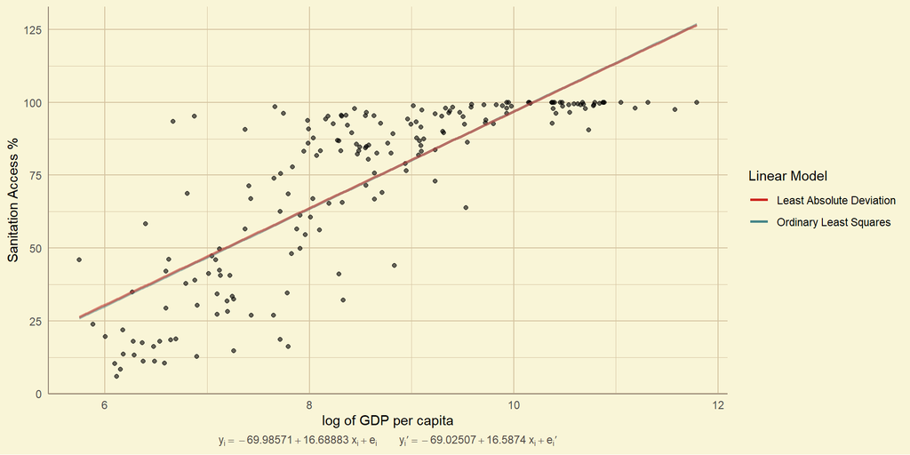